# Notas de Clase: Componentes principales II

El mapa de los estudiantes: qué perfiles hay y a quién le toca cada tutoría

Estadística Multidimensional · Universidad Distrital Francisco José de Caldas

Lunes 19 de octubre de 2026

# 1 Introducción: el encargo sigue

El sábado le respondimos a la coordinadora de la institución técnica que **sí** podía ordenar a sus estudiantes con un solo número, el puntaje global, pero que ese número dejaba por fuera a casi la mitad de los que necesitaban tutoría de escritura.

Nos volvió a escribir:

> *«Entendido: no me basta un número. Pero tampoco puedo manejar cinco listas. ¿Qué tipos de estudiante tengo? ¿Puedo armar grupos de tutoría por perfil? ¿Y cuántos estudiantes le tocan a cada tutoría?»*

La pregunta de hoy:

> **Si ponemos a cada estudiante en un mapa de dos dimensiones, ¿qué perfiles aparecen, se separan en grupos, y a quién le toca cada tipo de refuerzo?**

Antes de mirar a los estudiantes vamos a mirar **un caso donde los grupos sí se separan**, para saber qué aspecto tiene eso. Así, cuando miremos Saber, sabremos reconocer si lo que vemos se parece o no.

# 2 Objetivos de aprendizaje

Al terminar la sesión, cada estudiante debe poder:

1. Dibujar y leer **el mapa de las dos primeras componentes**: cada caso es un punto.
2. Leer **las flechas** de un biplot: qué dirección tiene cada variable y cuánto van juntas.
3. Distinguir en el mapa un caso donde **los grupos se separan** de uno donde **solo se desplazan**.
4. **Traducir el mapa a una decisión del cliente**, contada en casos concretos.

# 3 La base con la que llegamos

La misma limpieza de las sesiones pasadas.

```r
saber <- read.csv("PruebaSaber1.csv", sep = ";", fileEncoding = "latin1",
                  stringsAsFactors = FALSE)

s <- saber |>
  transmute(
    cuantitativo = MOD_RAZONA_CUANTITAT_PUNT,
    lectura      = MOD_LECTURA_CRITICA_PUNT,
    ciudadanas   = MOD_COMPETEN_CIUDADA_PUNT,
    ingles       = MOD_INGLES_PUNT,
    escritura    = MOD_COMUNI_ESCRITA_PUNT,
    global       = PUNT_GLOBAL,
    estrato      = FAMI_ESTRATOVIVIENDA,
    genero       = ESTU_GENERO
  )
s$id <- seq_len(nrow(s))

modulos  <- c("cuantitativo", "lectura", "ciudadanas", "ingles", "escritura")
etiqueta <- c(cuantitativo = "cuantitativo", lectura = "lectura", ciudadanas = "ciudadanas",
              ingles = "inglés", escritura = "escritura")

s <- s[s$estrato != "Empleado obrero u operario", ]            # fila corrida
s$ingles[s$ingles == 0] <- NA                                    # no presentaron inglés
for (m in modulos) s[[m]][s$id %in% c(671, 614) & s[[m]] == 0] <- NA   # ceros de las filas 671 y 614

s$estrato <- sub("Estrato ", "", s$estrato)
s$estrato[grepl("rural", s$estrato)] <- "Rural"
s$estrato[s$estrato == ""] <- NA
s$genero <- factor(s$genero, levels = c("F", "M"), labels = c("Mujer", "Hombre"))

sc <- s[complete.cases(s[modulos]), ]
nrow(sc)
```

```
## [1] 9907
```

# 4 Primero, un caso donde los grupos sí se separan: iris

**iris** son 150 flores de tres especies, con cuatro medidas de cada una: largo y ancho del sépalo y del pétalo. Las especies las clasificó un botánico, así que sabemos de antemano a qué grupo pertenece cada flor. Es el caso de libro: sirve para ver **cómo se ve un mapa cuando los grupos existen**.

Las cuatro medidas están en centímetros pero con rangos muy distintos (el pétalo mide de 1 a 7; su ancho, de 0,1 a 2,5), así que aquí **sí se estandariza**.

```r
pca_iris <- prcomp(iris[, 1:4], scale. = TRUE)
guarda_iris <- 100 * pca_iris$sdev^2 / sum(pca_iris$sdev^2)
round(guarda_iris, 1)
```

```
## [1] 73.0 22.9  3.7  0.5
```

```r
mapa_iris <- data.frame(c1 = pca_iris$x[, 1], c2 = pca_iris$x[, 2], especie = iris$Species)
```

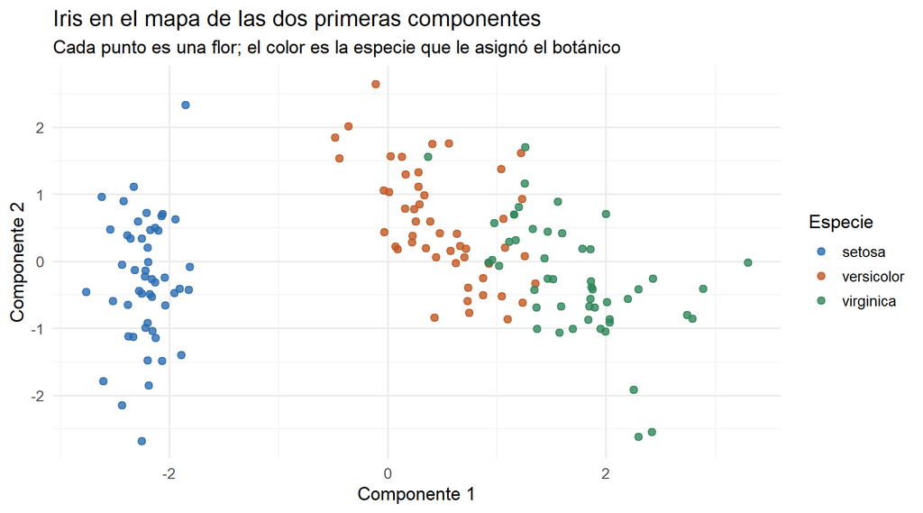

```r
ggplot(mapa_iris, aes(c1, c2, color = especie)) +
  geom_point(size = 2.3, alpha = 0.8) +
  scale_color_manual(values = c(setosa = "#2B6CB0", versicolor = "#C05621", virginica = "#2F855A"),
                     name = "Especie") +
  scale_x_continuous(labels = function(x) coma(x, 0)) +
  scale_y_continuous(labels = function(x) coma(x, 0)) +
  labs(title = "Iris en el mapa de las dos primeras componentes",
       subtitle = "Cada punto es una flor; el color es la especie que le asignó el botánico",
       x = "Componente 1", y = "Componente 2")
```

```r
c1 <- mapa_iris$c1; sp <- mapa_iris$especie
c(setosa_llega_hasta          = round(max(c1[sp == "setosa"]), 2),
  las_otras_empiezan_en       = round(min(c1[sp != "setosa"]), 2),
  virginica_metidas_en_versicolor = sum(c1[sp == "virginica"] < max(c1[sp == "versicolor"])),
  versicolor_metidas_en_virginica = sum(c1[sp == "versicolor"] > min(c1[sp == "virginica"])))
```

```
##              setosa_llega_hasta           las_otras_empiezan_en
##                           -1.81                           -0.49
## virginica_metidas_en_versicolor versicolor_metidas_en_virginica
##                           14.00                           28.00
```

> 📋 **Describir:** las dos primeras componentes guardan 95,8 de cada 100 partes de la información de las cuatro medidas. En el mapa, **setosa queda sola**: llega hasta -1,81 en la primera componente y las otras dos especies empiezan en -0,49. Versicolor y virginica se tocan: 14 virginicas caen en la zona de versicolor y 28 versicolor en la de virginica, de 50 cada una.

> 🔎 **Analizar:** **así se ve un grupo que existe:** una nube aparte, con un hueco vacío entre ella y las demás. Setosa se separa sin discusión; versicolor y virginica se separan **casi**. **Decisión:** este es el patrón que vamos a buscar en los estudiantes. Si aparece, la coordinadora puede armar grupos de tutoría por perfil. Si no aparece, tendrá que decidir de otra forma.

# 5 El mapa de los estudiantes

## 5.1 Las dos direcciones del mapa

Hacemos lo mismo con los cinco módulos. Como vimos el sábado, en Saber no hace falta estandarizar.

```r
pca <- prcomp(sc[modulos])
guarda <- 100 * pca$sdev^2 / sum(pca$sdev^2)

# El signo de una componente es arbitrario: lo fijamos para que se lea fácil.
# Componente 1 positiva = nivel general alto.
# Componente 2 positiva = escribe MEJOR de lo que haría esperar su nivel general.
signo1 <- sign(sum(pca$rotation[, 1])); signo2 <- sign(pca$rotation["escritura", 2])
sc$nivel  <- signo1 * pca$x[, 1]
sc$escr_r <- signo2 * pca$x[, 2]

c(guarda_la_1 = round(guarda[1], 1), guarda_la_2 = round(guarda[2], 1),
  el_mapa_guarda = round(sum(guarda[1:2]), 1),
  la_2_va_con_escritura = round(cor(sc$escr_r, sc$escritura), 3))
```

```
##           guarda_la_1           guarda_la_2        el_mapa_guarda
##                52.900                16.200                69.100
## la_2_va_con_escritura
##                 0.849
```

> 📋 **Describir:** el mapa de dos componentes guarda 69,1 de cada 100 partes de la información de los cinco módulos. La primera dirección es el **nivel general**; la segunda va 0,85 con escritura.

> 🔎 **Analizar:** es menos que en iris (95,8), pero alcanza para ver el panorama. En el mapa, **ir a la derecha es tener mejor nivel general; ir hacia arriba es escribir mejor de lo que ese nivel haría esperar.** **Decisión:** leemos el mapa con esas dos preguntas y recordamos que inglés, la tercera componente, no está dibujado.

## 5.2 El biplot: los estudiantes y los módulos en el mismo dibujo

Un **biplot** pone en el mismo dibujo a los estudiantes (puntos) y a los módulos (flechas).

> 📐 **La matemática, enunciada.** Cada flecha tiene como coordenadas los pesos del módulo en las dos componentes, multiplicados por lo que varía cada componente:

> $$\text{flecha del módulo } j =
> \big(w_{j1}\,\sqrt{\lambda_1},\;
> w_{j2}\,\sqrt{\lambda_2}\big)$$

> **En palabras:** la flecha apunta hacia donde crece ese módulo en el mapa, y es más larga cuanto mejor la representa el mapa. **El ángulo entre dos flechas dice cuánto van juntos los dos módulos**: ángulo pequeño, van juntos; ángulo recto, nada que ver; ángulo abierto, van en contra. Es una lectura aproximada, tan buena como lo que guarda el mapa.

```r
flechas <- data.frame(modulo = etiqueta[modulos],
                      x = signo1 * pca$rotation[, 1] * pca$sdev[1],
                      y = signo2 * pca$rotation[, 2] * pca$sdev[2])
angulo <- function(a, b) acos(sum(a * b) / sqrt(sum(a^2) * sum(b^2))) * 180 / pi
A <- outer(1:5, 1:5, Vectorize(function(i, j)
  angulo(unlist(flechas[i, c("x", "y")]), unlist(flechas[j, c("x", "y")]))))
dimnames(A) <- list(etiqueta[modulos], etiqueta[modulos])
round(A)
```

```
##              cuantitativo lectura ciudadanas inglés escritura
## cuantitativo            0       7         10      1        74
## lectura                 7       0          2      8        66
## ciudadanas             10       2          0     10        64
## inglés                  1       8         10      0        74
## escritura              74      66         64     74         0
```

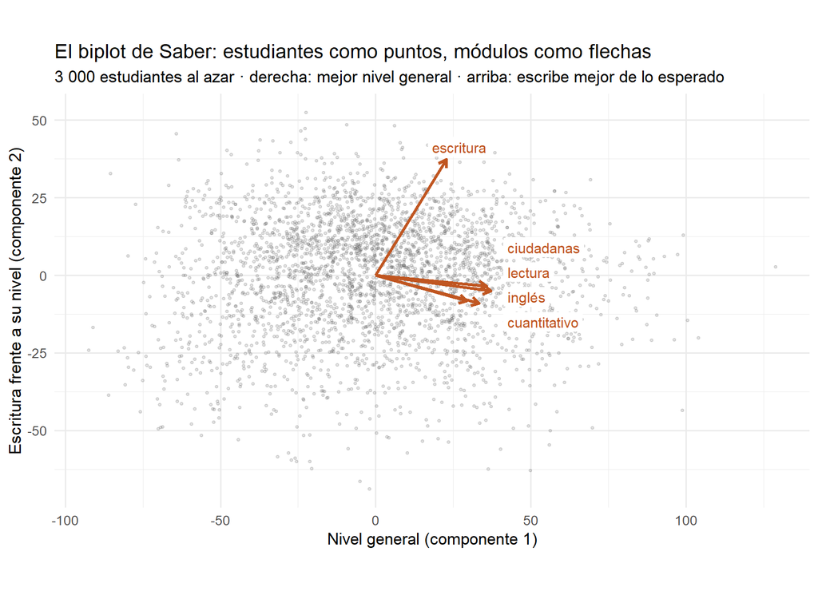

```r
set.seed(19)
muestra <- sc[sample(nrow(sc), 3000), ]
k <- 2.2   # las flechas se agrandan para que se vean sobre la nube
# las cuatro flechas del nivel general caen casi encima: sus etiquetas se apilan a la derecha
etiq_flechas <- flechas
cuatro <- etiq_flechas$modulo != "escritura"
orden <- order(-etiq_flechas$y[cuatro])
etiq_flechas$lx <- k * etiq_flechas$x + 3
etiq_flechas$ly <- k * etiq_flechas$y
etiq_flechas$lx[cuatro] <- max(k * flechas$x[cuatro]) + 4
etiq_flechas$ly[cuatro][orden] <- c(9, 1, -7, -15)
etiq_flechas$ly[!cuatro] <- k * flechas$y[!cuatro] + 4
etiq_flechas$lx[!cuatro] <- k * flechas$x[!cuatro] - 6

ggplot(muestra, aes(nivel, escr_r)) +
  geom_point(alpha = 0.15, size = 0.8, color = "grey30") +
  geom_segment(data = flechas, aes(x = 0, y = 0, xend = k * x, yend = k * y),
               arrow = arrow(length = unit(0.25, "cm")), color = "#C05621", linewidth = 1.1) +
  geom_label(data = etiq_flechas, aes(x = lx, y = ly, label = modulo), hjust = 0,
             color = "#C05621", size = 4, label.size = 0, fill = "white") +
  scale_x_continuous(labels = function(x) coma(x, 0)) +
  scale_y_continuous(labels = function(x) coma(x, 0)) +
  coord_equal() +
  labs(title = "El biplot de Saber: estudiantes como puntos, módulos como flechas",
       subtitle = "3 000 estudiantes al azar · derecha: mejor nivel general · arriba: escribe mejor de lo esperado",
       x = "Nivel general (componente 1)", y = "Escritura frente a su nivel (componente 2)")
```

> 📋 **Describir:** cuantitativo, lectura, ciudadanas e inglés apuntan casi al mismo lado: entre ellos hay a lo sumo 10 grados. La flecha de escritura se abre: está a entre 64 y 74 grados de las demás. Y la nube de estudiantes es **una sola mancha**, sin huecos.

> 🔎 **Analizar:** las cuatro flechas juntas son **el nivel general**: el que sube en uno sube en los otros tres. Escritura va por su cuenta, como vimos el sábado. Pero lo más importante es la nube: **no se ve ninguna isla como la de setosa.** No hay «tipos» de estudiante con un hueco entre ellos; hay un continuo. **Decisión:** la coordinadora no puede esperar que los datos le entreguen grupos hechos. Si quiere grupos de tutoría, **los tiene que definir ella**, con cortes en el mapa.

# 6 ¿Los grupos que ella conoce se separan en el mapa?

La coordinadora conoce a sus estudiantes por estrato y por género. ¿Esos grupos ocupan zonas distintas del mapa?

```r
sc$grupo_estrato <- case_when(sc$estrato == "1" ~ "Estrato 1",
                              sc$estrato %in% c("4", "5", "6") ~ "Estratos 4 a 6")
e1 <- sc$grupo_estrato %in% "Estrato 1"; e46 <- sc$grupo_estrato %in% "Estratos 4 a 6"
c(estudiantes_estrato_1 = sum(e1), estudiantes_estratos_4_a_6 = sum(e46),
  distancia_entre_promedios = round(mean(sc$nivel[e46]) - mean(sc$nivel[e1]), 1),
  variacion_tipica_del_nivel = round(sd(sc$nivel), 1),
  estrato_1_sobre_el_promedio_pct = round(100 * mean(sc$nivel[e1] > 0), 1),
  estrato_1_sobre_la_mediana_de_4_a_6_pct = round(100 * mean(sc$nivel[e1] > median(sc$nivel[e46])), 1))
```

```
##                   estudiantes_estrato_1              estudiantes_estratos_4_a_6
##                                  2892.0                                   327.0
##               distancia_entre_promedios              variacion_tipica_del_nivel
##                                    25.7                                    32.6
##         estrato_1_sobre_el_promedio_pct estrato_1_sobre_la_mediana_de_4_a_6_pct
##                                    35.2                                    19.6
```

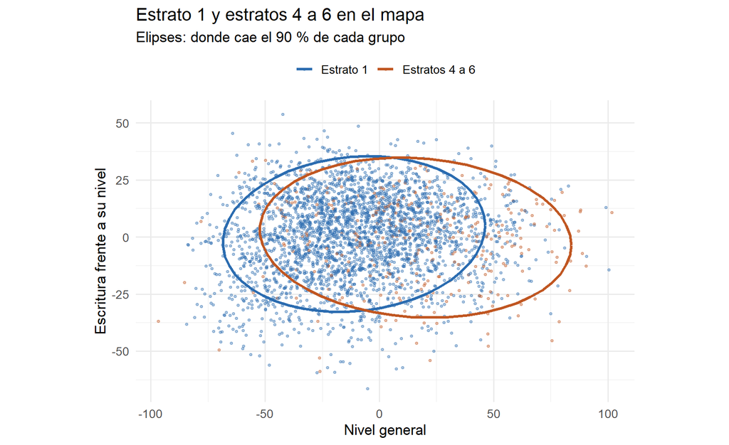

```r
sc |>
  filter(!is.na(grupo_estrato)) |>
  ggplot(aes(nivel, escr_r, color = grupo_estrato)) +
  geom_point(alpha = 0.35, size = 0.9) +
  stat_ellipse(level = 0.9, linewidth = 1.1) +
  scale_color_manual(values = c("Estrato 1" = "#2B6CB0", "Estratos 4 a 6" = "#C05621"), name = NULL) +
  scale_x_continuous(labels = function(x) coma(x, 0)) +
  scale_y_continuous(labels = function(x) coma(x, 0)) +
  coord_equal() +
  labs(title = "Estrato 1 y estratos 4 a 6 en el mapa",
       subtitle = "Elipses: donde cae el 90 % de cada grupo",
       x = "Nivel general", y = "Escritura frente a su nivel") +
  theme(legend.position = "top")
```

> 📋 **Describir:** entre el promedio del estrato 1 (2 892 estudiantes) y el de los estratos 4 a 6 (327) hay 25,7 puntos de nivel general, cuando la variación típica del nivel es 32,6. Pero 35,2 de cada 100 estudiantes de estrato 1 están **por encima del promedio**, y 19,6 de cada 100 superan a la mitad de los de estratos 4 a 6.

> 🔎 **Analizar:** el estrato **desplaza** la nube hacia la derecha, pero **no la separa**: las dos elipses se montan casi enteras. Es lo contrario de setosa. **Diferencia no es separación.** **Decisión:** asignar tutorías por estrato dejaría por fuera a estudiantes de estratos altos que la necesitan y se la daría a muchos de estrato 1 que no. El estrato no sirve para escoger a quién.

```r
c(mujeres_escriben_mejor_que_su_nivel_pct = round(100 * mean(sc$escr_r[sc$genero %in% "Mujer"] > 0), 1),
  hombres_escriben_mejor_que_su_nivel_pct = round(100 * mean(sc$escr_r[sc$genero %in% "Hombre"] > 0), 1))
```

```
## mujeres_escriben_mejor_que_su_nivel_pct hombres_escriben_mejor_que_su_nivel_pct
##                                    60.3                                    45.5
```

> 📋 **Describir:** en la dirección de escritura pasa algo parecido con el género: 60,3 de cada 100 mujeres escriben mejor de lo que haría esperar su nivel, contra 45,5 de cada 100 hombres.

> 🔎 **Analizar:** hay una diferencia, pero de nuevo **no es separación**: casi la mitad de los hombres también está arriba. **Decisión:** el género tampoco sirve para escoger a quién va a la tutoría de escritura. Lo que sirve es **el lugar de cada estudiante en el mapa**.

# 7 La decisión: el mapa de tutorías

Si los grupos no vienen hechos, la coordinadora los define con dos cortes. Proponemos uno sencillo: **quedar más de una variación típica por debajo** en cada dirección.

- Muy abajo en **nivel general** → tutoría general.
- Muy abajo en **escritura frente a su nivel** → tutoría de escritura.

```r
corte1 <- -sd(sc$nivel); corte2 <- -sd(sc$escr_r)
sc$tutoria <- case_when(
  sc$nivel < corte1 & sc$escr_r < corte2 ~ "Las dos",
  sc$nivel < corte1                      ~ "General",
  sc$escr_r < corte2                     ~ "Escritura",
  TRUE                                   ~ "Ninguna")
tabla_tutorias <- as.data.frame(table(tutoria = sc$tutoria))
tabla_tutorias$de_cada_100 <- round(100 * tabla_tutorias$Freq / nrow(sc), 1)
tabla_tutorias
```

| tutoria | Freq | de_cada_100 |
| --- | --- | --- |
| Escritura | 1221 | 12.3 |
| General | 1257 | 12.7 |
| Las dos | 381 | 3.8 |
| Ninguna | 7048 | 71.1 |

```r
n_tut <- setNames(tabla_tutorias$Freq, tabla_tutorias$tutoria)
solo_escr <- sc$tutoria == "Escritura"
escr_fuera_global <- 100 * mean(sc$global[solo_escr] > quantile(sc$global, 0.20))
c(solo_escritura_fuera_del_20_bajo_del_global_pct = round(escr_fuera_global, 1))
```

```
## solo_escritura_fuera_del_20_bajo_del_global_pct
##                                            88.5
```

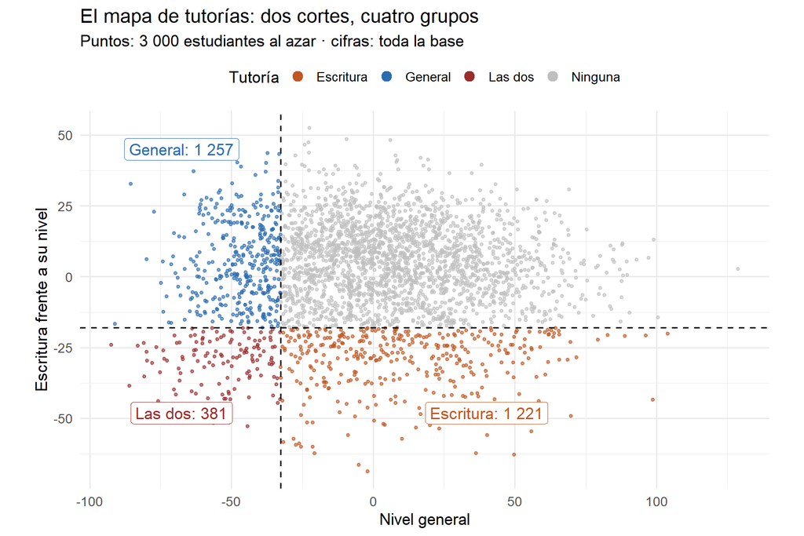

```r
colores <- c("Las dos" = "#9B2C2C", "General" = "#2B6CB0", "Escritura" = "#C05621", "Ninguna" = "grey75")
ggplot(sc[sc$id %in% muestra$id, ], aes(nivel, escr_r, color = tutoria)) +
  geom_point(alpha = 0.6, size = 1) +
  geom_vline(xintercept = corte1, linetype = "dashed") +
  geom_hline(yintercept = corte2, linetype = "dashed") +
  annotate("label", x = corte1 - 35, y = 45, label = paste("General:", miles(n_tut["General"])),
           color = "#2B6CB0", label.size = 0) +
  annotate("label", x = 40, y = corte2 - 30, label = paste("Escritura:", miles(n_tut["Escritura"])),
           color = "#C05621", label.size = 0) +
  annotate("label", x = corte1 - 35, y = corte2 - 30, label = paste("Las dos:", miles(n_tut["Las dos"])),
           color = "#9B2C2C", label.size = 0) +
  scale_color_manual(values = colores, name = "Tutoría") +
  guides(color = guide_legend(override.aes = list(size = 3.5, alpha = 1))) +
  scale_x_continuous(labels = function(x) coma(x, 0)) +
  scale_y_continuous(labels = function(x) coma(x, 0)) +
  coord_equal() +
  labs(title = "El mapa de tutorías: dos cortes, cuatro grupos",
       subtitle = "Puntos: 3 000 estudiantes al azar · cifras: toda la base",
       x = "Nivel general", y = "Escritura frente a su nivel") +
  theme(legend.position = "top")
```

> 📋 **Describir:** con los dos cortes, 1 257 estudiantes van solo a tutoría general, 1 221 solo a escritura y 381 a las dos. El resto, 7 048, no necesita ninguna según este criterio.

> 🔎 **Analizar:** los 1 221 de solo escritura son **estudiantes con nivel general aceptable que escriben peor de lo esperado**: 88,5 de cada 100 de ellos no están en el 20 % más bajo del global, así que una lista por global no los habría visto. Y los dos grupos de tutoría son casi del mismo tamaño, así que el programa de escritura **no es un apéndice**: necesita tanta capacidad como el general. **Decisión:** la coordinadora puede armar dos programas de tamaño parecido y un grupo pequeño con las dos tutorías. El corte de «una variación típica» es una decisión suya, no de la técnica: si tiene menos cupos, lo corre hacia abajo.

# 8 Qué no dice el mapa

- **No dice que haya tipos de estudiante.** Los grupos de tutoría los definimos nosotros con cortes; la nube es un continuo.
- **No muestra inglés.** El mapa guarda 69,1 de cada 100; inglés vive en la tercera componente. Si la institución tiene tutoría de inglés, hay que hacer el mismo ejercicio con ese módulo.
- **No explica por qué.** Que el estrato desplace la nube no dice que el estrato cause el puntaje: con el estrato viajan el colegio, el computador, el tiempo libre.

# 9 La puerta a lo que viene

| Lo que vimos hoy | La pregunta que queda | Dónde se responde |
| --- | --- | --- |
| Cuatro flechas van juntas y escritura va sola | ¿Hay **habilidades** detrás de los puntajes? ¿Una o dos? | **Sáb 24 oct** · Análisis factorial I |
| Los nombres de las direcciones los pusimos nosotros | ¿Se puede girar el mapa para que cada dirección tenga un nombre claro? | **Lun 26 oct** · Análisis factorial II |
| Los grupos se desplazan pero no se separan | ¿Cómo se prueba si dos grupos son distintos en los cinco módulos a la vez? | **Sáb 7 nov** · Taller de Hotelling |

# 10 Actividad práctica

Con **el dataset de su equipo** y **el cliente de su caso de negocio**:

1. **El mapa.** Dibujen sus casos en el plano de las dos primeras componentes. ¿Qué tanto guarda?
2. **Las flechas.** Hagan el biplot. ¿Qué variables van juntas? ¿Cuál va sola?
3. **Los grupos.** Coloreen el mapa por una variable de grupo de su base. ¿Se separan como setosa, o solo se desplazan?
4. **La decisión.** Propongan un corte en el mapa que le sirva a su cliente, y cuenten cuántos casos caen en cada zona.

# 11 Preguntas conceptuales

1. En iris, setosa queda sola en el mapa. ¿Qué tendría que verse en Saber para decir que hay «tipos» de estudiante?
2. Dos flechas forman un ángulo de 7 grados. ¿Qué dice eso de los dos módulos?
3. El estrato mueve la nube 25,7 puntos de nivel general. ¿Por qué eso no alcanza para asignar tutorías por estrato?
4. ¿Por qué el mapa de Saber guarda menos información que el de iris, y qué se pierde?
5. Los cortes de «una variación típica por debajo» los escogimos nosotros. ¿Qué cambia si la institución tiene la mitad de cupos?
6. ¿Cuál de estas afirmaciones es correcta? **(a)** Si el promedio de dos grupos es distinto, los grupos se separan en el mapa. **(b)** Un biplot muestra casos y variables en el mismo dibujo. **(c)** El ángulo entre dos flechas mide cuál variable es más importante. **(d)** El mapa encuentra automáticamente los grupos de tutoría.

# 12 Conclusión: lo que le entregamos al cliente

- **No hay tipos de estudiante hechos.** A diferencia de las flores de iris, los estudiantes forman una sola nube, sin huecos. Los grupos de tutoría hay que definirlos.
- **El mapa tiene dos direcciones con nombre:** el nivel general, donde cuatro módulos van juntos, y escritura, que va por su cuenta.
- **Estrato y género desplazan la nube pero no la separan.** No sirven para escoger a quién va a tutoría: diferencia no es separación.
- **La decisión:** dos cortes en el mapa dan dos programas de tamaño parecido —general y escritura— y un grupo pequeño que necesita los dos. Cada estudiante sabe por qué está en su tutoría.

Lo que usamos hoy se llama **biplot de componentes principales**. Lo que hicimos fue convertir cinco puntajes en un mapa y el mapa en una lista de tutorías.

# 13 Próxima clase

**Sábado 24 de octubre · Análisis factorial I.**

Un nuevo cliente: una empresa que contrata técnicos pregunta si la prueba mide **una habilidad o dos**. Hoy vimos que cuatro flechas van juntas y una va sola; el sábado vemos si detrás de eso hay habilidades, y en qué se diferencia esa pregunta de la de hoy.